# **NOTE:** Use File > Save a copy in Drive to make a copy before doing anything else

# Project 6: Data Exploration and Visualization

### Overview

In this project, you will apply data exploration and visualization techniques to a real-world dataset of your choice. You'll practice using pandas for data analysis and create meaningful visualizations to gain insights from your data. This project builds on your Python programming skills while introducing you to the exciting world of data science.

In [Lab7](https://colab.research.google.com/drive/15QvSh0csZaCU-OuuPIfpWx5wLDDjmqK4?usp=sharing), you explore the titanic dataset and you should use it as a sample and pick a dataset of your interest to do a similar data exploration and visualization.

### Project Objectives

- Find and select a dataset from a real-world data source
- Formulate a clear inquiry question based on your chosen dataset
- Perform exploratory data analysis using pandas functions
- Create at least two meaningful data visualizations
- Analyze your findings and answer your inquiry question
- Reflect on the insights gained through data exploration

### Data Sources

You can choose from various online data sources such as:

- [Kaggle](https://www.kaggle.com/datasets) - Wide variety of datasets
- [data.gov](https://www.data.gov/) - U.S. government data
- [Our World in Data](https://ourworldindata.org/) - Global development data
- [GitHub](https://github.com/datasets) - Curated datasets
- [Google Dataset Search](https://datasetsearch.research.google.com/) - Search for datasets
- Or any other reliable data source you find interesting

## Part 1: Dataset Selection and Initial Exploration

#### TODO Tasks:

1. Select Your Dataset: Choose a dataset that interests you. Make sure it has at least 100 rows and multiple columns with different data types (e.g., numerical, categorical, dates).

Please create either text or code cells in between the TODO tasks to do the work.

I chose a dataset on Pokémon and each of their stats from Kaggle. It has 1,014 rows and multiple columns with different data types such as Ability(str) and Speed(int).

2. Import Libraries: Import the necessary libraries (pandas, matplotlib, seaborn) at the beginning of your notebook by creating code cells below this text cell.

```python
import pandas as pd
import matplotlib.pyplot as plt
import seaborn as sns
```

3. Load Your Data: Load your chosen dataset using pandas and save it to a pandas dataframe. Please create a code cell below this text cell to do it.

```python
# Code imported from Kaggle

import kagglehub

# Download latest version
path = kagglehub.dataset_download("crinklybrain2003/pokmon-base-stats-dataset")

print("Path to dataset files:", path)
```

```
Using Colab cache for faster access to the 'pokmon-base-stats-dataset' dataset.
Path to dataset files: /kaggle/input/pokmon-base-stats-dataset
```

```python
"""
I used Gemini to import the dataset and put it into a Pandas dataframe
Prompt: Code that saves the dataset as a Pandas dataframe
"""
import os

# List files in the downloaded path
files_in_path = os.listdir(path)
print("Files in the dataset directory:", files_in_path)

# Assuming the main data file is a CSV and can be identified by name
csv_file = None
for f in files_in_path:
    if f.endswith('.csv'):
        csv_file = f
        break

if csv_file:
    file_path = os.path.join(path, csv_file)
    df = pd.read_csv(file_path)
    print(f"Loaded '{csv_file}' into a DataFrame.")
else:
    print("No CSV file found in the downloaded dataset.")
```

```
Files in the dataset directory: ['pokemon_combined.csv']
Loaded 'pokemon_combined.csv' into a DataFrame.
```

4. Data Summary: Use the following functions to do inital exploration your dataset:
- info() - Display information about the dataset structure
- describe() - Show statistical summary of numerical columns
- head() - Display the first 5 rows (df.head())
- shape - Show the dimensions of the dataset (e.g. df.shape)
- columns - Get the column names (e.g. df.columns)

You may use 5 code cells below this text cell to accomplish it.

```python
df.info()
```

```
<class 'pandas.core.frame.DataFrame'>
RangeIndex: 1014 entries, 0 to 1013
Data columns (total 17 columns):
 #   Column           Non-Null Count  Dtype
---  ------           --------------  -----
 0   Name             1014 non-null   object
 1   Type             1014 non-null   object
 2   Species          1014 non-null   object
 3   Height           1014 non-null   float64
 4   Weight           1014 non-null   float64
 5   Abilities        1014 non-null   object
 6   Catch rate       1014 non-null   int64
 7   Base Friendship  1014 non-null   int64
 8   Base Exp.        1014 non-null   int64
 9   Growth Rate      1014 non-null   object
 10  Gender           1014 non-null   object
 11  HP               1014 non-null   int64
 12  Attack           1014 non-null   int64
 13  Defense          1014 non-null   int64
 14  Sp. Atk          1014 non-null   int64
 15  Sp. Def          1014 non-null   int64
 16  Speed            1014 non-null   int64
dtypes: float64(2), int64(9), object(6)
memory usage: 134.8+ KB
```

```python
df.describe()
```

|  | Height | Weight | Catch rate | Base Friendship | Base Exp. | HP | Attack | Defense | Sp. Atk | Sp. Def | Speed |
| --- | --- | --- | --- | --- | --- | --- | --- | --- | --- | --- | --- |
| count | 1014.000000 | 1014.000000 | 1014.000000 | 1014.000000 | 1014.000000 | 1014.000000 | 1014.000000 | 1014.000000 | 1014.000000 | 1014.000000 | 1014.000000 |
| mean | 1.356706 | 71.732249 | 94.411243 | 46.523669 | 151.075937 | 70.612426 | 79.608481 | 73.893491 | 71.715976 | 71.076923 | 68.119329 |
| std | 3.356350 | 132.212009 | 75.950220 | 18.637471 | 85.182049 | 27.659913 | 32.121431 | 30.854665 | 32.164407 | 27.826603 | 30.244717 |
| min | 0.100000 | 0.100000 | 3.000000 | 0.000000 | 0.000000 | 1.000000 | 5.000000 | 5.000000 | 10.000000 | 20.000000 | 5.000000 |
| 25% | 0.525000 | 8.625000 | 45.000000 | 50.000000 | 65.000000 | 50.000000 | 55.000000 | 50.000000 | 47.250000 | 50.000000 | 45.000000 |
| 50% | 1.000000 | 28.650000 | 60.000000 | 50.000000 | 158.000000 | 68.000000 | 75.000000 | 70.000000 | 65.000000 | 67.000000 | 65.000000 |
| 75% | 1.600000 | 71.150000 | 140.000000 | 50.000000 | 187.000000 | 85.000000 | 100.000000 | 90.000000 | 91.000000 | 90.000000 | 90.000000 |
| max | 100.000000 | 999.900000 | 255.000000 | 140.000000 | 635.000000 | 255.000000 | 185.000000 | 250.000000 | 194.000000 | 250.000000 | 200.000000 |

```python
df.head()
```

|  | Name | Type | Species | Height | Weight | Abilities | Catch rate | Base Friendship | Base Exp. | Growth Rate | Gender | HP | Attack | Defense | Sp. Atk | Sp. Def | Speed |
| --- | --- | --- | --- | --- | --- | --- | --- | --- | --- | --- | --- | --- | --- | --- | --- | --- | --- |
| 0 | Bulbasaur | Grass Poison | Seed Pokémon | 0.7 | 6.9 | 1. OvergrowChlorophyll (hidden ability) | 45 | 50 | 64 | Medium Slow | 87.5% male, 12.5% female | 45 | 49 | 49 | 65 | 65 | 45 |
| 1 | Ivysaur | Grass Poison | Seed Pokémon | 1.0 | 13.0 | 1. OvergrowChlorophyll (hidden ability) | 45 | 50 | 142 | Medium Slow | 87.5% male, 12.5% female | 60 | 62 | 63 | 80 | 80 | 60 |
| 2 | Venusaur | Grass Poison | Seed Pokémon | 2.4 | 155.5 | Thick Fat | 45 | 50 | 281 | Medium Slow | 87.5% male, 12.5% female | 80 | 100 | 123 | 122 | 120 | 80 |
| 3 | Charmander | Fire | Lizard Pokémon | 0.6 | 8.5 | 1. BlazeSolar Power (hidden ability) | 45 | 50 | 62 | Medium Slow | 87.5% male, 12.5% female | 39 | 52 | 43 | 60 | 50 | 65 |
| 4 | Charmeleon | Fire | Flame Pokémon | 1.1 | 19.0 | 1. BlazeSolar Power (hidden ability) | 45 | 50 | 142 | Medium Slow | 87.5% male, 12.5% female | 58 | 64 | 58 | 80 | 65 | 80 |

```python
df.shape
```

```
(1014, 17)
```

```python
df.columns
```

```
Index(['Name', 'Type', 'Species', 'Height', 'Weight', 'Abilities',
       'Catch rate', 'Base Friendship', 'Base Exp.', 'Growth Rate', 'Gender',
       'HP', 'Attack', 'Defense', 'Sp. Atk', 'Sp. Def', 'Speed'],
      dtype='object')
```

```python
pokemon_with_catch_rate_255 = df[df['Catch rate'] == 255]['Name']
display(pokemon_with_catch_rate_255)
""" This code is to see which Pokémon have a catch rate of 255
It creates a dataframe from the existing dataframe and gets the
Name for each Pokémon with a Catch rate value of 255
I did use Gemini to generate this code with the prompt:
'Get the name value of each Pokémon with a Catch rate value of 255' """
```

|  | Name |
| --- | --- |
| 9 | Caterpie |
| 12 | Weedle |
| 15 | Pidgey |
| 18 | Rattata |
| 20 | Spearow |
| ... | ... |
| 905 | Tarountula |
| 916 | Smoliv |
| 920 | Nacli |
| 948 | Wiglett |
| 1012 | Terapagos |

86 rows × 1 columns

**dtype:** object

```
" This code is to see which Pokémon have a catch rate of 255\nIt creates a dataframe from the existing dataframe and gets the \nName for each Pokémon with a Catch rate value of 255\nI did use Gemini to generate this code with the prompt: \n'Get the name value of each Pokémon with a Catch rate value …
```

```python
pokemon_with_catch_rate_3 = df[df['Catch rate'] == 3]['Name']
display(pokemon_with_catch_rate_3)
"""
This code is to see which Pokémon have a catch rate of 3
(It's the same as the previous code, just changed to see the
Pokémon with a Catch rate of 3)
"""
```

|  | Name |
| --- | --- |
| 137 | Articuno |
| 138 | Zapdos |
| 139 | Moltres |
| 143 | Mewtwo |
| 236 | Raikou |
| ... | ... |
| 996 | Miraidon |
| 1002 | Okidogi |
| 1003 | Munkidori |
| 1004 | Fezandipiti |
| 1013 | Pecharunt |

75 rows × 1 columns

**dtype:** object

```
" \nThis code is to see which Pokémon have a catch rate of 3\n(It's the same as the previous code, just changed to see the \nPokémon with a Catch rate of 3)\n"
```

5. Inquiry Question: Write a clear, specific question that you want to answer using your dataset by creating a text cell below and **write the question in bold please.**

For example:

- "How has the average temperature changed in major cities over the past decade?"
- "What factors are most strongly correlated with housing prices?"
- "Is there a relationship between education level and income?"

# **My inquiry question is: Is there a relationship between the Pokémon's weight and it's catch rate?**

I chose this dataset and question because as someone who plays the games, I've always wondered if how big the Pokémon is is a determining factor of the catch rate. Knowing this would also be helpful when I'm playing if it is a major determining factor.

## Part 2: Data Visualization and Analysis

#### TODO Tasks:

1. Data Cleaning (if necessary): Check for and handle any missing values, duplicates, or data quality issues.

**NOTE: This could be a daunting task even for seasoned data scientists. My suggestion is to use a dataset that is already clean if you can for the purpose of completing this assignment in a week.**

Examples:

- Checking for missing values: df.isnull().sum()
- Dropping rows with any missing values: df.dropna(inplace=True)
- Dropping columns with all missing values: df.dropna(axis=1, how='all', inplace=True)
- Removing duplicate row: df.drop_duplicates(inplace=True)

```python
df.isnull().sum()
# checking for missing values, no values missing
```

|  | 0 |
| --- | --- |
| Name | 0 |
| Type | 0 |
| Species | 0 |
| Height | 0 |
| Weight | 0 |
| Abilities | 0 |
| Catch rate | 0 |
| Base Friendship | 0 |
| Base Exp. | 0 |
| Growth Rate | 0 |
| Gender | 0 |
| HP | 0 |
| Attack | 0 |
| Defense | 0 |
| Sp. Atk | 0 |
| Sp. Def | 0 |
| Speed | 0 |

**dtype:** int64

2. Create Visualizations: Create at least 2 different types of visualizations that help answer your research question. Choose from:
- Bar charts
- Line plots
- Scatter plots
- Histograms
- Box plots
- Heatmaps
- Any other appropriate visualization
3. Customize Your Plots: Make sure your visualizations are clear and informative by:
- Adding appropriate titles
- Labeling axes
- Using colors effectively
- Adding legends when necessary

Please create code cells below this to create your visualizations.

**Key**

255 - 33.3% catch rate at full HP (with a regular Pokéball)

3 - 0.4% catch rate at full HP (with a regular Pokéball)

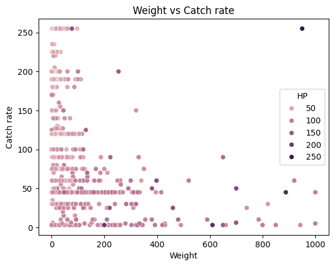

```python
sns.scatterplot(x='Weight', y='Catch rate', hue="HP", data=df)
plt.title("Weight vs Catch rate")
```

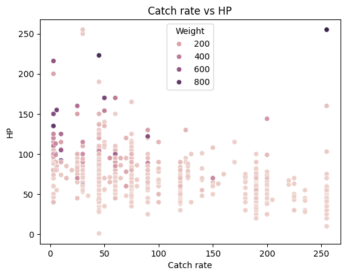

```python
sns.scatterplot(x="Catch rate", y="HP", hue="Weight", data=df)
plt.title("Catch rate vs HP")
```

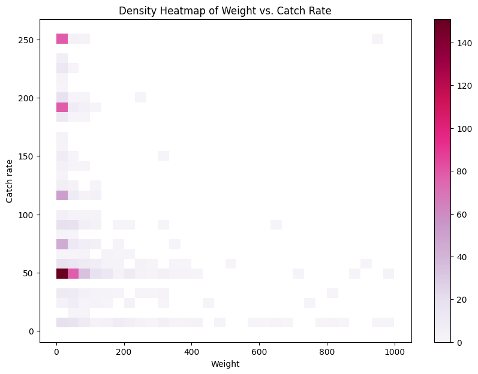

```
' \nI used Gemini to generate a heatmap, I wanted to try it and see what it looks like.\nPrompt: Code for making a heat map with the x value the Weight and the hue value the Catch rate\nThe color is for the count, how many Pokémon have that specific weight and catch rate\n'
```

```python
plt.figure(figsize=(10, 7))
sns.histplot(x='Weight', y='Catch rate', data=df, bins=30, cmap='PuRd', cbar=True)
plt.title('Density Heatmap of Weight vs. Catch Rate')
plt.show()
"""
I used Gemini to generate a heatmap, I wanted to try it and see what it looks like.
Prompt: Code for making a heat map with the x value the Weight and the hue value the Catch rate
The color is for the count, how many Pokémon have that specific weight and catch rate
"""
```

4. Analysis: Write 1-2 paragraphs discussing:
- Whether your research question can be answered with the available data
- What insights you discovered through your visualizations
- Any unexpected or interesting findings
- Limitations of your analysis
- Suggestions for further investigation

Please create a text cell below this cell to write your analysis.

**Question: Is weight a deciding factor of the catch rate?**

With the available data, weight does seem to be one of the deciding factors of it's catch rate. There are more Pokémon with a catch rate of 255 when their weight is lighter than 200. There's only one outlier with a catch rate of 255 with a weight of 1000. Where we see the strongest relationship between the weight and the catch rate is in Pokémon with weights lighter than 200. I noticed that most of the Pokémon with a ctach rate of 3 were Legendary or Mythical Pokémon. Also, the Pokémon with a catch rate of 255 were generally basic Pokémon which does make sense.

With my visualizations I choose to also look at the base HP of the Pokémon because usually heavier Pokémon will have more base HP, and vise versa. However, I was surprised to see that there was a variety of Pokémon in each HP category with varying catch rates. For example, there are Pokémon with 50 base HP that have a low catch rate and ones that have a high catch rate.

A limitation of my data is that there aren't as many Pokémon with weights of 400+ so the data could be skewed a little bit because there is less data points. For example, weight might not be that big of factor for it's catch rate, but because there aren't as many Pokémon with heavier weights, our data could be inaccurate. For furthur investigations, I would suggest to look at the Pokémon species because some Pokémon have more skittish natures that I think can affect their catch rate, so it would be good to see if that is a factor. However, to get a full analysis I would suggest looking at all of the Pokémon statistics such as abilities and where they spawn because I know Pokémon that spawn on the first routes usually have higher catch rates.

## NOTE: If you use a local dataset, you MUST submit the dataset along with your notebook to get credit.

- Download your notebook as CS110_Project6.ipynb
- Ensure all TODO tasks are completed
- Make sure your code runs without errors
- Include clear comments explaining your work
- Submit the notebook file

## Grading Criteria (5 points)

- Dataset Selection: Appropriate choice of dataset with sufficient complexity (0.5 point)
- Inquiry Question: Clear, specific, and answerable with the chosen data (1 point)
- Data Exploration: Proper use of pandas functions for initial analysis (0.5 point)
- Visualizations: At least 2 clear, well-formatted, and relevant plots (1 point)
- Analysis: Thoughtful interpretation of findings and answer to research question (1 point)
- Code Quality: Clean, commented, and well-organized code (1 point)

Remember: The goal is not just to create visualizations, but to use them to gain meaningful insights about your data. Think like a data scientist and let your curiosity guide your exploration!